# Function documentation and dependencies

R package development workshop  
Module 2

Forwards teaching team

## Overview

- Documenting functions with roxygen2
- NAMESPACE: exporting functions
- Dependencies
- NAMESPACE: importing functions

# Function documentation with roxygen2

## roxygen2

The [**roxygen2**](https://roxygen2.r-lib.org/index.html) package generates documentation from specially formatted comments.

comments -> `.Rd files` -> HTML

This powers R’s help system, e.g. `?function` and package websites.

**roxygen2** 8.0.0 was released May 2026, with over 100 improvements and bug fixes.

[This blog post](https://opensource.posit.co/blog/2026-05-01_roxygen2-8-0-0/) outlines the major changes.

```r
packageVersion("roxygen2")
```

```
[1] '8.0.0'
```

## roxygen2 comments

We write comments above the function code, e.g.

```r
#' @param x A numeric vector.
```

- `#'` is a roxygen comment.
- `@param` is a roxygen tag.
- The `@param` tag takes an argument: the name of the parameter
- The remaining text (until the next tag in the file) is the documentation relevant to the tag.

## Common tags

There are four tags you’ll use for most functions:

| Tag | Purpose |
| --- | --- |
| @param arg | Describe inputs |
| @examples | Show how the function works |
| @return | Describe the return value (not needed if `NULL`) |
| @export | Add this tag if the function should be user-visible |

Usual RStudio shortcuts work in the @examples section, allowing you to run code interactively.

## The description block

The roxygen comment should start with a description block.

- First sentence is the **title**.
- Next paragraph is the **description**.
- Everything else is the **details** (optional).

```
#' Title in Title Case of up to 65 Characters
#'
#' Mandatory description of what the function does.
#' Should be a short paragraph of a few lines only.
#'
#' The details section is optional and may be several paragraphs. It can even
#' contain sub-sections (not illustrated here).
```

## RStudio helps you get started

Put your cursor inside a function, then select ‘Insert Roxygen Skeleton’ from the Code menu.

[figure not shown]

```r
#' Title
#'
#' @param animal
#' @param sound
#'
#' @return
#' @export
#'
#' @examples
animal_sounds <- function(animal, sound) {
  stopifnot(is.character(animal) & length(animal) == 1)
  stopifnot(is.character(sound) & length(sound) == 1)
  paste0("The ", animal, " goes ", sound, "!")
}
```

## Example roxygen documentation

```r
#' Sort a Numeric Vector in Decreasing Order
#'
#' Sort a numeric vector so that the values are in deceasing order.
#' Missing values are optionally removed or put last.
#'
#' @param x A numeric vector.
#' @param na.rm A logical value indicating whether to remove missing values
#' before sorting.
#' @return A vector with the values sorted in descreasing order.
#' @export
#'
#' @examples
#' x <- c(3, 7, 2, NA)
#' high_to_low(x)
#' high_to_low(x, na.rm = TRUE)
```

## R documentation file

roxygen2 converts the roxygen block to an `.Rd` file in the `/man` directory

```
% Generated by roxygen2: do not edit by hand
% Please edit documentation in R/high_to_low.R
\name{high_to_low}
\alias{high_to_low}
\title{Sort a Numeric Vector in Decreasing Order}
\usage{
high_to_low(x, na.rm = FALSE)
}
\arguments{
\item{x}{A numeric vector.}
\item{na.rm}{A logical value indicating whether to remove missing values
before sorting.}
}
\value{
...
```

## HTML file

When the package is installed, the `.Rd` is converted by R to HTML on demand

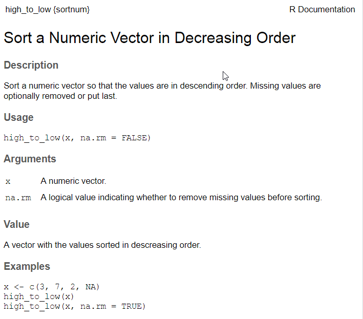

## Regular documentation workflow

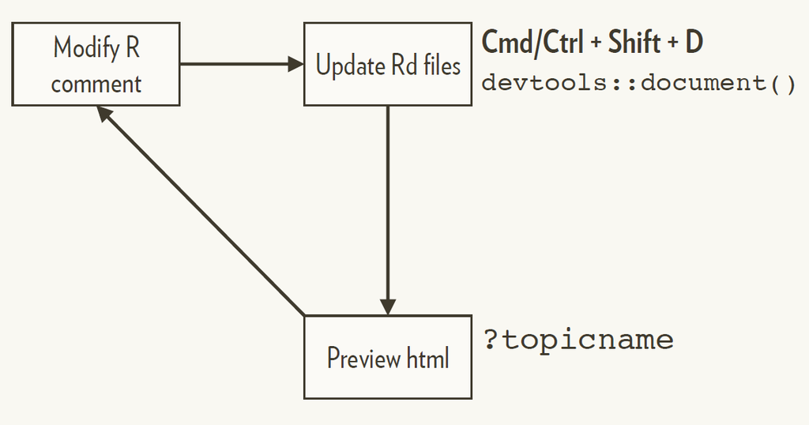

You must have loaded the package with `load_all()` at least once.

# NAMESPACE: exports

## A namespace splits functions into two classes

| Internal | External |
| --- | --- |
| Only for use within package | For use by others |
| Documentation optional | Must be documented |
| Easily changed | Changing could break other people’s code |

## Default NAMESPACE

- It is best to export functions explicitly
- The `NAMESPACE` file as created by `usethis::create_package()` does *not* export anything by default.

**Warning**

A package created from the RStudio menus via File > New Project > New Directory > R Package creates a `NAMESPACE` that exports everything by default, with `exportPattern("^[[:alpha:]]+")`

This is a good reason *not* to do this: always call `usethis::create_package()` to create a package.

For similar reasons, also avoid `package.skeleton()`.

## Exporting functions

```r
#' @export
fun1 <- function(...) {}
```

When we call `devtools::document()`, an `export()` directive will be added to NAMESPACE for each function that has an `#' @export` comment.

```
# Generated by roxygen2: do not edit by hand

export(fun1)
```

## What to export

Only export functions that you want your package users to use, i.e. those that are relevant to the purpose of the package.

Don’t export internal helpers, e.g.

```r
# Defaults for NULL values
`%||%` <- function(a, b) if (is.null(a)) b else a

# Remove NULLs from a list
compact <- function(x) {
  x[!vapply(x, is.null, logical(1))]
}
```

**Note**

Using the ‘Insert Roxygen Skeleton’ option adds an `@export` tag.

## Your turn

For the `animal_sounds` function:

1. Insert a Roxygen skeleton using the RStudio helper.
2. Create a draft documentation file with `devtools::document()` or `Cmd/Ctrl + Shift + D`.
3. Click on “Diff” in the Git pane and view the changes that have been made.
4. Preview the HTML help with `?animal_sounds`.
5. Fill in the Roxygen skeleton for `animal_sounds()`, recreating the documentation file and previewing the HTML help to view your updates.
6. When you have finished editing, run `devtools::document()` to ensure the `.Rd` file is in sync. Make a git commit with your updated `R/animal_sounds.R` file, the updated NAMESPACE, and the new `man/animal_sounds.Rd` file.

## .Rd Markup

`.Rd` files recognise LaTeX-like mark-up in most text-based fields, e.g.

```
#' This is a convenience function that is a wrapper around
#' \code{\link{sort.int}}.
```

Details can be found in the [Writing R documentation files](https://cran.r-project.org/doc/manuals/r-release/R-exts.html#Writing-R-documentation-files) section of the Writing R Extensions manual.

## Using markdown

Most commonly used mark-up is easier with markdown (and can be mixed with `.Rd` mark-up).

- Text formatting: `**bold**`, `_italic_`, `` `code` ``
- Create links
  - To a function in the same package: `[func()]`
  - To a function in a different package: `[pkg::func()]`
  - With different link text, e.g. `[link text][func()]`

For more details, see the [(R)Markdown support](https://roxygen2.r-lib.org/articles/rd-formatting.html) vignette.

## Your turn

1. Add some details to the help page for `animal_sounds()`, with a link to `paste0()` and some markdown syntax.
2. Add a link to a function from a package you don’t have installed (perhaps `grumpy::read_npy()`).
3. Run `devtools::document()` and check the link in the help page. What happens?
4. Run `devtools::check()`. Does the link cause problems?
5. Delete the link to the package you don’t have installed and run `devtools::document()` again.
6. Commit all your changes to the git repo.

# Dependencies

## No `library()` calls!

We **cannot** use `library()` calls in R packages.

We need another way to access functions in other packages, and to ensure that users of our package have those other packages installed on their system too.

To do this, we can take **dependencies** on other packages.

## Dependencies

Dependencies are other R packages that our package uses. There are three types of dependency:

**Imports**: required packages, will be installed when our package is installed if they are not already installed.

**Suggests**: optional packages, e.g. only used for development; only used in documentation. *Not* installed automatically with our package.

**Depends**: essentially deprecated for packages, may be used to specify a minimum required version of R (i.e., version of the core packages).

## Imported packages

In DESCRIPTION

```
Imports:
    pkgname1
    pkgname2
```

Use `::` to access functions

```r
new_function <- function(x, y, z) {
  w <- pkgname1::imported_function(x, y)
  pkgname2::imported_function(w, z)
}
```

## Suggested packages

In DESCRIPTION

```
Suggests:
    pkgname
```

In package functions or examples, handle the case where **pkgname** is not available:

```r
if (!requireNamespace("pkgname", quietly = TRUE)){
  warning("pkgname must be installed to perform this function",
          "returning NULL")
  return(NULL)
}
```

## `use_package()`

`use_package()` will modify the DESCRIPTION and remind you how to use the function.

By default, packages will be added to “Imports”.

```r
usethis::use_package("cli")
```

```
✔ Adding cli to Imports field in DESCRIPTION.
☐ Refer to functions with `cli::fun()`.
```

```r
usethis::use_package("withr", type = "Suggests")
```

```
✔ Adding withr to Suggests field in DESCRIPTION.
☐ Use `requireNamespace("withr", quietly = TRUE)` to test if
  withr is installed.
☐ Then directly refer to functions with `withr::fun()`.
```

# NAMESPACE: imports

## Accessing functions in other packages

Once we have taken a dependency on a *package*, we have a choice about how to access the *functions* in that package:

- directly, with `pkgname::function()`
- importing the function, then just calling `function()`

## Advantages of `pkgname::function()`

- Makes it really clear to you, and other readers of your code, where functions have come from.
- Requires no further setup
- Necessary to dissambiguate when have two functions with the same name in two different packages

## Advantages of importing a function

- Don’t need to keep typing `pkgname::` - this can get tedious and make code much more noisy
- Code is slightly more efficient to run (though only by about 2 microseconds)
  - Difference will only be noticeable if running 100,000+ calls in a tight loop
- Some packages already have function names that make it clear where they are from, e.g. **stringr** with `str_*()`
- Necessary for infix operators, e.g. `%>%`
  - N.B. recommendation is now to use native pipe `|>` in packages instead.

Largely a matter of personal preference. A hybrid approach is also fine!

## Aside: `%>%` vs `|>`

The native pipe, `|>`, has been available in R since 4.1.0, and we now prefer this to importing the `%>%` pipe from **magrittr**.

There are then two options:

- Depend on R >= 4.1.0, with this in DESCRIPTION:

```
Depends:
    R (>= 4.1.0)
```

- Use the methods outlined in [this tidyverse blog post](https://www.tidyverse.org/blog/2023/04/base-vs-magrittr-pipe/#using-the-native-pipe-in-packages) to ensure the package can still work with older versions of R.

See [slides 28-31 here](https://warwick-stats-resources.github.io/r-foundations-2025/slides/02-data-wrangling/index.html#/a-note-about-pipes-vs) for more about the pipes, and [this blog post](https://ivelasq.rbind.io/blog/understanding-the-r-pipe/).

## Importing functions into the package manually

```r
#' @importFrom purrr keep modify

col_summary <- function(df, fun) {
  stopifnot(is.data.frame(df))

  df |>
    keep(is.numeric) |>
    modify(fun)
}
```

Here, the `@importFrom` tag is placed above the function in which the imported function is used.

## Package-level import file, manually

Imports belong to the package, not to individual functions, so alternatively you can recognise this by storing them in a central location, e.g. `R/animalsounds-package.R`

```r
#' @importFrom purrr keep modify
#' @importFrom magrittr %>%
NULL
```

This removes the possibility of multiple (redundant) imports of the same function. But harder to remember to remove import if function changes! It’s a matter of personal taste.

## `usethis::use_import_from()`

There can be several steps to importing a function. `usethis::use_import_from()` takes care of all of them.

This is a (preferred) alternative to writing `@importFrom` tags manually.

It will first create the package documentation file `R/animalsounds-package.R` (if it doesn’t already exist – you will also need to agree to this).

```r
usethis::use_import_from("purrr", c("keep", "modify"))
```

```
✔ Adding 'purrr' to Imports field in DESCRIPTION
✔ Adding '@importFrom purrr keep', '@importFrom purrr modify' to 'R/animalsounds-package.R'
✔ Writing 'NAMESPACE'
✔ Loading animalsounds
```

## You *can* import all functions from a package…

It may be tempting to import all the functions from a package:

```r
#' @import purrr
col_summary <- function(df, fun) {
  stopifnot(is.data.frame(df))

  df |>
    keep(is.numeric) |>
    map_dfc(fun)
}
```

## … but don’t!

**It is dangerous:**

```r
#' @import pkg1
#' @import pkg2
fun <- function(x) {
  fun1(x) + fun2(x)
}
```

Works today…

… but next year, what if **pkg2** adds a `fun1` function?

**And not clear:**

You lose direct evidence in your package of which functions come from which packages.

## Metapackages

It is bad practice to import “metapackages” (i.e. packages that are collections of packages), such as **tidyverse**.

See the blog post https://www.tidyverse.org/blog/2018/06/tidyverse-not-for-packages/ for more details.

## Documenting dependencies

| DESCRIPTION | NAMESPACE |
| --- | --- |
| Makes **package** available | Makes **function** available |
| Mandatory | Optional (can use `::` instead) |
| `use_package()` | `use_import_from()` |

## Example: rlang and cli

Currently we are using `stopifnot()` for argument validation

```r
stopifnot(is.character(animal) & length(animal) == 1)
stopifnot(is.character(sound) & length(sound) == 1)
```

We might instead use `rlang::is_character()` with `cli::cli_abort()`

```r
sound <- c("woof", "bark")

if (!rlang::is_character(sound, n = 1)) {
  cli::cli_abort("`sound` must be a single string!")
}
```

```
Error:
! `sound` must be a single string!
```

## Aside: informative messages with `cli`

**cli** functions can combine glue interpolation and inline classes to produce informative, nicely-formatted error messages.

In `animal_sounds()` we can use

```r
cli::cli_abort(
  c("{.var animal} must be a single string!",
    "i" = "It was {.type {animal}} of length {length(animal)} instead.")
)
```

This gives the error message

```r
animal_sounds(c("dog", "cat"), c("woof", "miaow"))
```

```
Error in `animal_sounds()`:
! `animal` must be a single string!
ℹ It was a character vector of length 2 instead.
```

## Your turn

1. Use `use_package()` to add `rlang` and `cli` to `Imports`.
2. Update `animal_sounds()` to use `is_character()` to check the arguments and `cli_abort` to throw an informative error if necessary, using `::` to fully qualify the function calls.
3. Load all and try giving `animal_sounds()` invalid inputs for animal and/or sound.
4. Commit your changes to git.
5. Push your commits for this session.

## Best practice: helper functions

We’ve essentially repeated code to check the `animal` and `sound` arguments. Better practice is to use a helper function.

Try the following:

```r
check_arg <- function(arg, n = 1) {
  if (!rlang::is_character(arg, n = n)) {
    cli::cli_abort(
      c("{.var arg} must be a single string!",
        "i" = "It was {.type {arg}} of length {length(arg)} instead.")
    )
  }
}
```

## Improvement 1: actual arg name

```r
check_arg <- function(arg, n = 1) {
  if (!rlang::is_character(arg, n = n)) {
    cli::cli_abort(
      c(
        "{.var {rlang::caller_arg(arg)}} must be a single string!",
        "i" = "It was {.type {arg}} of length {length(arg)} instead."
      )
    )
  }
}
```

## Improvement 2: calling function

```r
check_arg <- function(arg, n = 1) {
  if (!rlang::is_character(arg, n = n)) {
    cli::cli_abort(
      c(
        "{.var {rlang::caller_arg(arg)}} must be a single string!",
        "i" = "It was {.type {arg}} of length {length(arg)} instead."
      ),
      call = rlang::caller_env()
    )
  }
}
```

## Improvement 3: incorporating `n`

```r
check_arg <- function(arg, n = 1) {
  if (!rlang::is_character(arg, n = n)) {
    cli::cli_abort(
      c(
        "{.var {rlang::caller_arg(arg)}} must be a character vector of length {n}!",
        "i" = "It was {.type {arg}} of length {length(arg)} instead."
      ),
      call = rlang::caller_env()
    )
  }
}
```

# Minute cards

- [Cohort 1](https://tally.so/r/A74PDz)
- [Cohort 2](https://tally.so/r/q4JZW9)

# End matter

## References

Wickham, H and Bryan, J, *R Packages* (2nd edn, in progress), https://r-pkgs.org.

R Core Team, *Writing R Extensions*, https://cran.r-project.org/doc/manuals/r-release/R-exts.html

## License

Licensed under a Creative Commons Attribution-NonCommercial-ShareAlike 4.0 International License ([CC BY-NC-SA 4.0](https://creativecommons.org/licenses/by-nc-sa/4.0/)).